# Assignment 1: Estimating CDF and PDF

Matthew Gray

Due: Tuesday 2/3/2026

## **Assignment Objectives**

- Develop a clear technical understanding of nonparametric cumulative distribution function (CDF) estimation and various kernel density estimators.
- Translate mathematical formulas into R functions and apply them to solve related problems.
- Create effective visualizations to demonstrate your understanding of key concepts in the following questions.

## **Question 1: Cumulative Distribution Function (CDF) Estimation**

The following failure times (in hours) were observed for 8 electronic components:

23, 45, 67, 89, 112, 156, 189, 245

1. Write an R function implementing the ECDF $\hat{F}_n(t)$ according to its mathematical definition. Validate your implementation using R’s ecdf() function on the given data, with comparison based on their step functions.

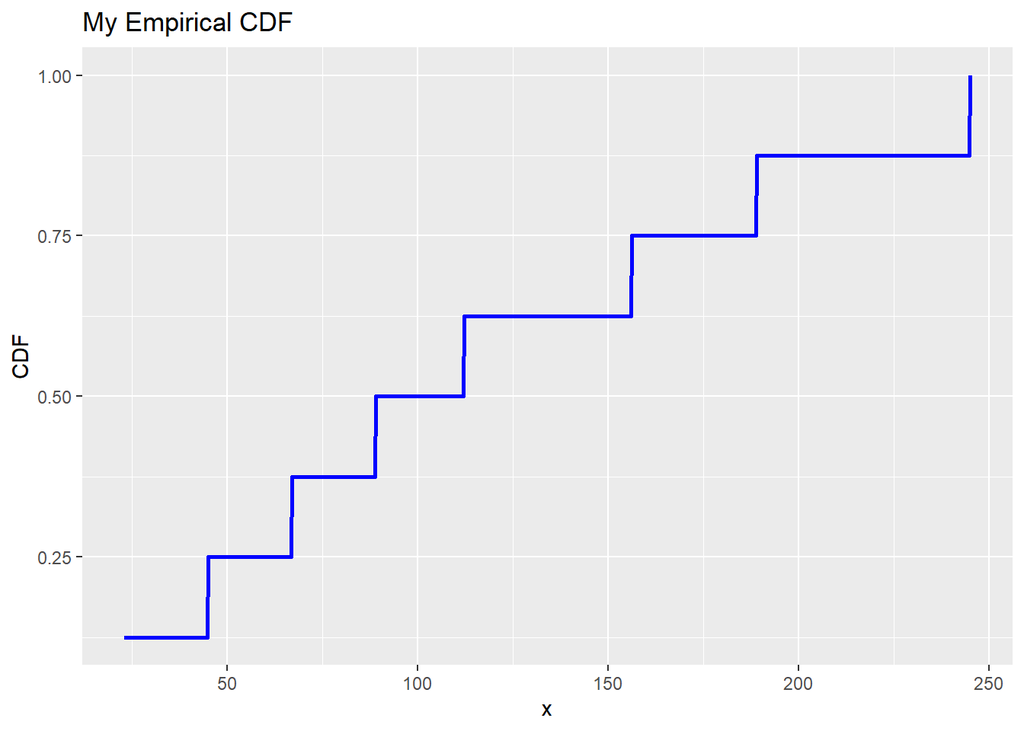

```r
# Custom ECDF function
my_ecdf <- function(data) {
  data <- sort(data)
  n <- length(data)

  function(x) {
    findInterval(x, data) / n
  }
}

# Sample data
empirical_data <- c(23,45,67,89,112,156,189,245)

# Create ECDF function
my_empirical_cdf <- my_ecdf(empirical_data)

# x-values for plotting
x_vals <- seq(min(empirical_data), max(empirical_data), length.out = 1000)

# Build plot data frame
plot_df <- data.frame(
  x = x_vals,
  my_Empirical = my_empirical_cdf(x_vals)
)

# Plot
ggplot(plot_df, aes(x, my_Empirical)) +
  geom_line(color = "blue", linewidth = 1) +
  labs(title = "My Empirical CDF", x = "x", y = "CDF")
```

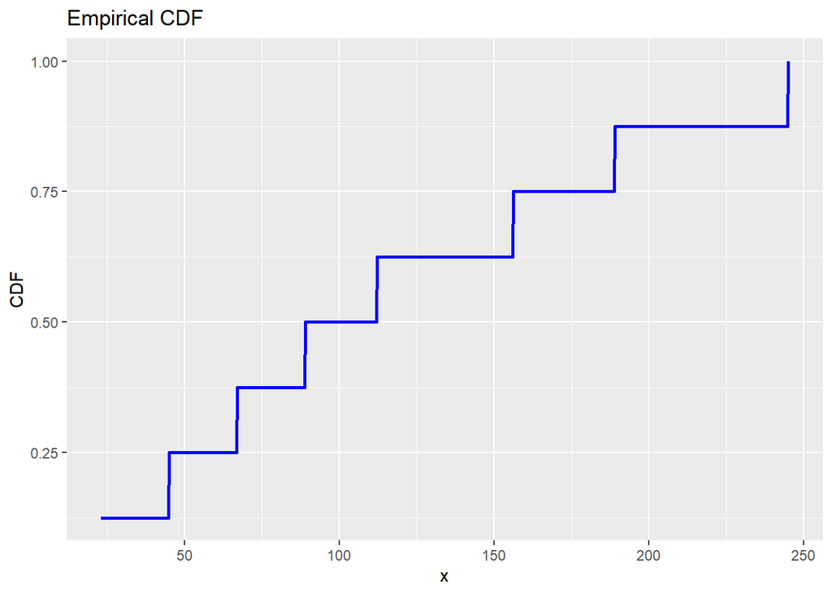

```r
# Below is the implementation of ECDF function

# Record sample data
empirical_data <- c(23,45,67,89,112,156,189,245)

# Generate empirical CDF
empirical_cdf <- ecdf(empirical_data)

# Build data frame for plotting
x_vals <- seq(min(empirical_data), max(empirical_data), length.out = 1000)

plot_df <- data.frame(
  x = x_vals,
  Empirical = empirical_cdf(x_vals)
)

ggplot(plot_df, aes(x, Empirical)) +
  geom_line(color = "blue", linewidth = 1) +
  labs(title = "Empirical CDF", x = "x", y = "CDF")
```

2. A colleague claims that the probability of failure before 100 hours is 0.5 based on these data. Do you agree? Explain your reasoning using the empirical cumulative distribution function (ECDF).

Yes, I agree with this assessment. The height of the ECDF at x = 100 is 0.50.

## **Question 2: Density Function Estimation**

Consider the following failure times from a mechanical system:

12.3, 14.7, 15.2, 16.8, 18.1, 19.4, 20.6, 22.3, 23.9, 25.4

1. Create a histogram of the data using 3 equally spaced bins. What is the estimated density in each bin? Describe the shape of the histogram’s distribution.

The histogram is bell-shaped. From smallest to largest fail times (left to right), the densities of these bins are 0.06870229, 0.09160305, and 0.06870229.When you multiply each of these densities by the bin width (4.366667), you can find the probability of falling within each bin. Left to right those probabilities are 0.3, 0.4, and 0.3.

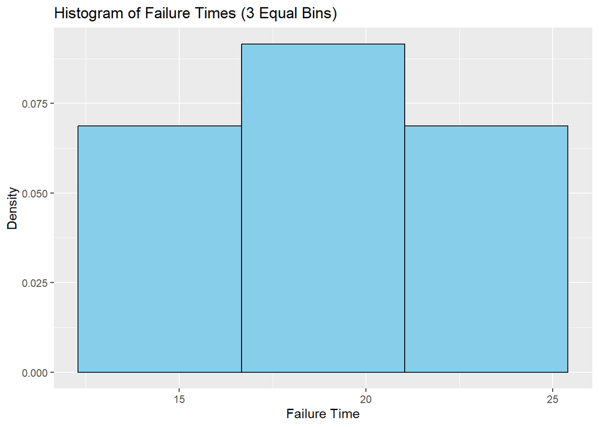

```r
## Data
fail_times <- c(12.3, 14.7, 15.2, 16.8, 18.1, 19.4, 20.6, 22.3, 23.9, 25.4)

## Step 1: Compute three equally spaced bins
min_val <- min(fail_times)
max_val <- max(fail_times)
range_val <- max_val - min_val
bin_width <- range_val / 3

breaks <- seq(min_val, max_val, length.out = 4)

## Step 2: Count observations in each bin
bin_counts <- hist(fail_times, breaks = breaks, plot = FALSE)$counts

## Step 3: Compute density in each bin
n <- length(fail_times)
bin_density <- bin_counts / (n * bin_width)

## Step 4: Build a histogram using density
library(ggplot2)

ggplot(data.frame(fail_times), aes(x = fail_times)) +
  geom_histogram(aes(y = ..density..),
                 breaks = breaks,
                 color = "black",
                 fill = "skyblue") +
  labs(title = "Histogram of Failure Times (3 Equal Bins)",
       x = "Failure Time",
       y = "Density")
```

2. Write an R function that computes kernel density estimates using a Gaussian kernel with $h=2$. Validate your implementation against R’s built-in density() function.

$$\hat{f}_h(t) = \frac{1}{nh}\sum_{i=1}^n K\left( \frac{t-t_i}{h}\right),
\ \ \text{ where } \ \ K(u) = \frac{1}{\sqrt{2\pi}} e^{-u^2/2}.$$

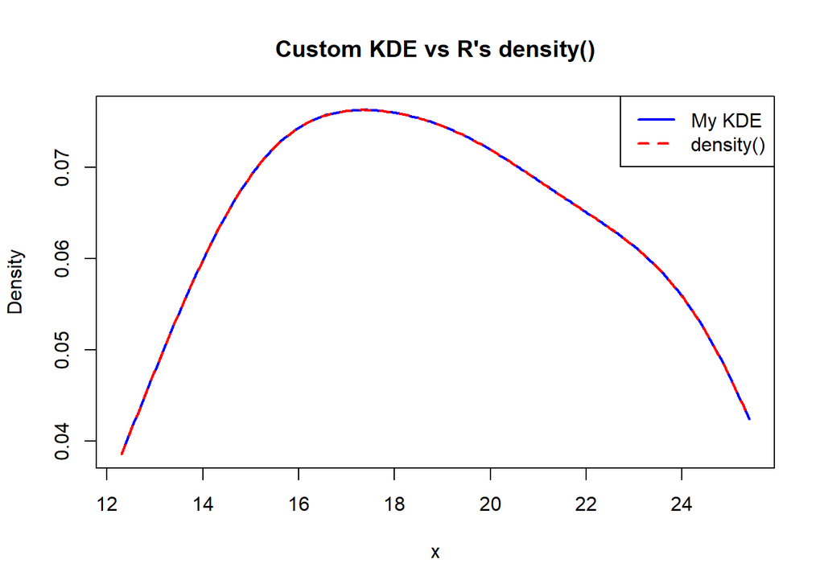

```r
my_kde <- function(x, eval_points, h) {
  n <- length(x)

  # Gaussian kernel
  gaussian_kernel <- function(u) {
    dnorm(u)   # standard normal density
  }

  # Compute KDE at each evaluation point
  sapply(eval_points, function(t) {
    u <- (t - x) / h
    mean(gaussian_kernel(u)) / h
  })
}

fail_times <- c(12.3, 14.7, 15.2, 16.8, 18.1, 19.4, 20.6, 22.3, 23.9, 25.4)

# Evaluation grid
grid <- seq(min(fail_times), max(fail_times), length.out = 200)

# Custom KDE
my_est <- my_kde(fail_times, grid, h = 2)

# Built-in KDE
r_est <- density(fail_times, bw = 2, kernel = "gaussian",
                 from = min(grid), to = max(grid), n = 200)

plot(grid, my_est, type = "l", col = "blue", lwd = 2,
     main = "Custom KDE vs R's density()",
     ylab = "Density", xlab = "x")
lines(r_est$x, r_est$y, col = "red", lwd = 2, lty = 2)
legend("topright", legend = c("My KDE", "density()"),
       col = c("blue", "red"), lwd = 2, lty = c(1,2))
```

```r
max(abs(my_est - r_est$y))
```

```
[1] 3.776587e-06
```

3. Write a custom R function that computes kernel density estimates using the Epanechnikov kernel with $h=2$. Validate your implementation by comparing results with R’s built-in density() function for Gaussian kernel estimation.

$$\hat{f}_h(t) = \frac{1}{nh}\sum_{i=1}^n K\left( \frac{t-t_i}{h}\right),
\ \ \text{ where } \ \ K(u) = \frac{3}{4}(1 - u^2) \ \ \text{ for } \ \
|u| \le 1.$$

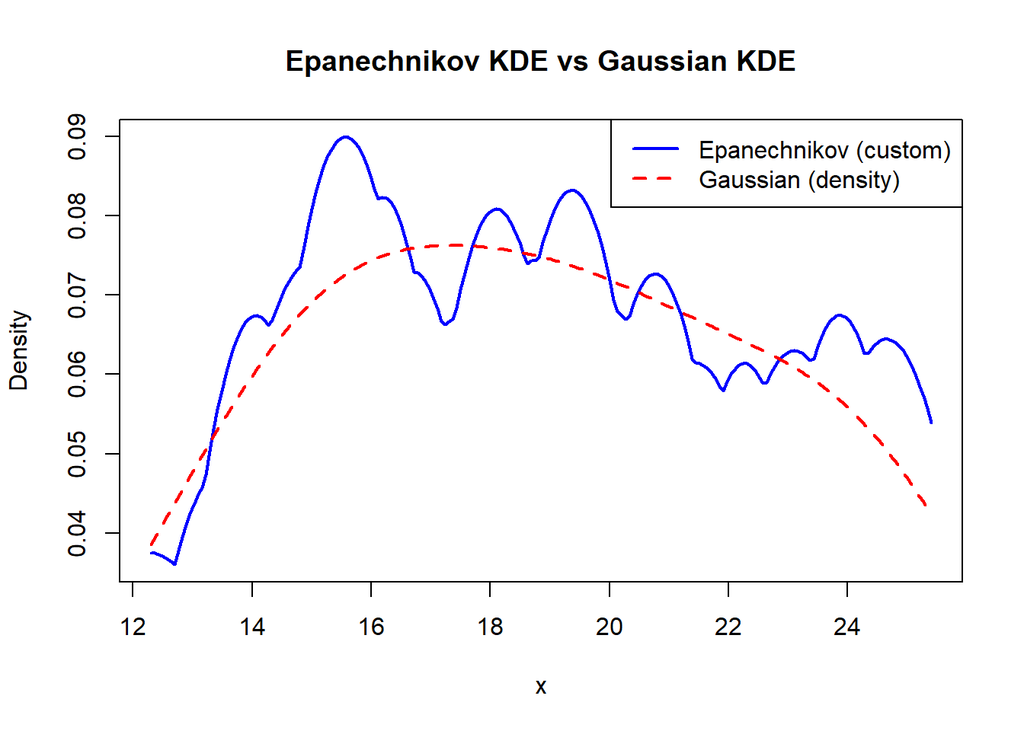

```r
my_kde_epanechnikov <- function(x, eval_points, h) {
  n <- length(x)

  # Epanechnikov kernel
  epan_kernel <- function(u) {
    ifelse(abs(u) <= 1, 0.75 * (1 - u^2), 0)
  }

  # KDE evaluated at each point
  sapply(eval_points, function(t) {
    u <- (t - x) / h
    mean(epan_kernel(u)) / h
  })
}

fail_times <- c(12.3, 14.7, 15.2, 16.8, 18.1, 19.4, 20.6, 22.3, 23.9, 25.4)

# Evaluation grid
grid <- seq(min(fail_times), max(fail_times), length.out = 200)

# Custom Epanechnikov KDE
my_epan <- my_kde_epanechnikov(fail_times, grid, h = 2)

# Built-in Gaussian KDE
r_gauss <- density(fail_times, bw = 2, kernel = "gaussian",
                   from = min(grid), to = max(grid), n = 200)

plot(grid, my_epan, type = "l", col = "blue", lwd = 2,
     main = "Epanechnikov KDE vs Gaussian KDE",
     xlab = "x", ylab = "Density")

lines(r_gauss$x, r_gauss$y, col = "red", lwd = 2, lty = 2)

legend("topright",
       legend = c("Epanechnikov (custom)", "Gaussian (density)"),
       col = c("blue", "red"), lwd = 2, lty = c(1,2))
```

```r
max(abs(my_epan - r_gauss$y))
```

```
[1] 0.01761433
```

4. How does the choice of kernel (Gaussian vs. Epanechnikov) affect the density estimate? For both kernel estimators applied to this dataset, what happens when we select $h=1.5$ versus $h=2.5$?

Gaussian and Epanechnikov follow the same general shape, but Epanechnikov is more jagged given the same value for h. When you increase h, the density estimate becomes smoother for both Gaussian and Epanechnikov.

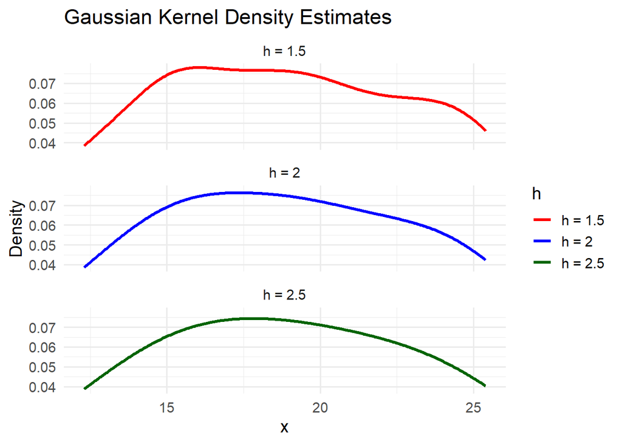

```r
# --- Custom KDE: Gaussian ---
my_kde_gaussian <- function(x, eval_points, h) {
  sapply(eval_points, function(t) {
    u <- (t - x) / h
    mean(dnorm(u)) / h
  })
}

# --- Custom KDE: Epanechnikov ---
my_kde_epan <- function(x, eval_points, h) {
  epan <- function(u) ifelse(abs(u) <= 1, 0.75 * (1 - u^2), 0)
  sapply(eval_points, function(t) {
    u <- (t - x) / h
    mean(epan(u)) / h
  })
}

# Data
fail_times <- c(12.3, 14.7, 15.2, 16.8, 18.1, 19.4, 20.6, 22.3, 23.9, 25.4)

# Evaluation grid
grid <- seq(min(fail_times), max(fail_times), length.out = 400)

# Bandwidths
h_vals <- c(1.5, 2.0, 2.5)

# ---------- Gaussian KDE Plot ----------
gauss_list <- lapply(h_vals, function(h) {
  data.frame(
    x = grid,
    Density = my_kde_gaussian(fail_times, grid, h),
    h = paste0("h = ", h)
  )
})

gauss_df <- do.call(rbind, gauss_list)

ggplot(gauss_df, aes(x, Density, color = h)) +
  geom_line(linewidth = 1.2) +
  facet_wrap(~ h, ncol = 1) +
  labs(
    title = "Gaussian Kernel Density Estimates",
    x = "x",
    y = "Density"
  ) +
  scale_color_manual(values = c("red", "blue", "darkgreen")) +
  theme_minimal(base_size = 14)
```

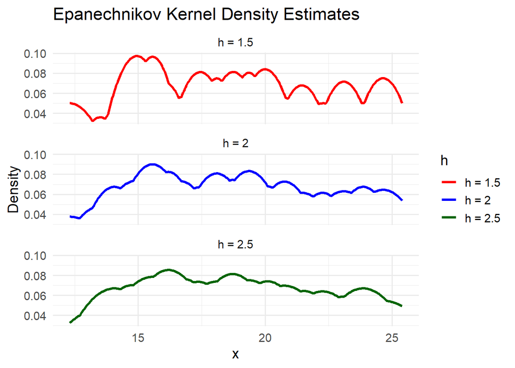

```r
# ---------- Epanechnikov KDE Plot ----------
epan_list <- lapply(h_vals, function(h) {
  data.frame(
    x = grid,
    Density = my_kde_epan(fail_times, grid, h),
    h = paste0("h = ", h)
  )
})

epan_df <- do.call(rbind, epan_list)

ggplot(epan_df, aes(x, Density, color = h)) +
  geom_line(linewidth = 1.2) +
  facet_wrap(~ h, ncol = 1) +
  labs(
    title = "Epanechnikov Kernel Density Estimates",
    x = "x",
    y = "Density"
  ) +
  scale_color_manual(values = c("red", "blue", "darkgreen")) +
  theme_minimal(base_size = 14)
```